# The Solution to Assignment 2

Xiaojun Sun

Saturday, July 12, 2014

Dear all WISE R Club members. :smile: Here comes the solution to assignment2. Because assignment 2 is more difficult than assignment 1, I advise you to read this solution manual more carefully to make sure you understand every single code.

### Question 1

I define the factorial function in this way.

```r
Fac <- function(n) if (n==1|n==0) 1 else n*Fac(n-1)
```

Now test it!

```r
c(Fac(0),Fac(3),Fac(5))
```

```
## [1]   1   6 120
```

### Question 2

To start with, I read the `grades.txt` dataset to create data frame.

```r
grades <- read.table("grades.txt", header=TRUE,stringsAsFactors=FALSE)
```

#### Question 2.1

To plot the boxplot, we should reshape the data frame `grades` at first.

```r
library(reshape2)
gradex <- melt(grades,id="name")
```

We can see what is in the new data frame `gradex`.

```r
head(gradex)
```

```
##     name variable value
## 1 丁聪华     Math    63
## 2 孙蝶妃     Math    73
## 3 许娇翔     Math    78
## 4 崔子希     Math    74
## 5 樊瑶芳     Math    81
## 6 阮恭琴     Math    88
```

```r
str(gradex)
```

```
## 'data.frame':    900 obs. of  3 variables:
##  $ name    : chr  "丁聪华" "孙蝶妃" "许娇翔" "崔子希" ...
##  $ variable: Factor w/ 3 levels "Math","Chinese",..: 1 1 1 1 1 1 1 1 1 1 ...
##  $ value   : int  63 73 78 74 81 88 84 96 78 96 ...
```

Then we plot the boxplot just like Figure 6.12.

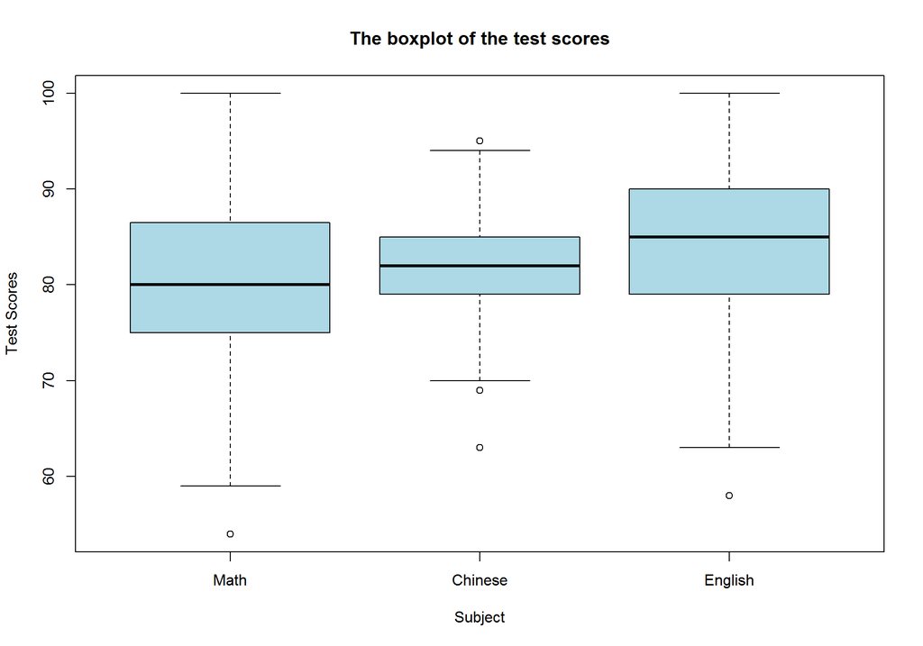

```r
boxplot(value ~ variable, data=gradex, col="lightblue",
        main="The boxplot of the test scores",
        xlab="Subject", ylab="Test Scores")
```

#### Question 2.2

To calculate `Sum` and get the 80th, 60th, 40th and 20th percentile of it,

```r
Sum <- rowSums(grades[,2:4])
x <- quantile(Sum, c(0.8,0.6,0.4,0.2))
```

To grade the students,

```r
grades <- cbind(grades, Sum)
grades$grade[Sum >= x[1]] <-"A+"
grades$grade[Sum < x[1] & Sum >= x[2]] <-"A"
grades$grade[Sum < x[2] & Sum >= x[3]] <-"B"
grades$grade[Sum < x[3] & Sum >= x[4]] <-"C"
grades$grade[Sum < x[4]] <-"D"
str(grades)
```

```
## 'data.frame':    300 obs. of  6 variables:
##  $ name   : chr  "丁聪华" "孙蝶妃" "许娇翔" "崔子希" ...
##  $ Math   : int  63 73 78 74 81 88 84 96 78 96 ...
##  $ Chinese: int  80 81 88 76 84 83 85 89 82 76 ...
##  $ English: int  77 74 82 86 86 92 92 98 81 91 ...
##  $ Sum    : num  220 228 248 236 251 263 261 283 241 263 ...
##  $ grade  : chr  "D" "D" "B" "D" ...
```

#### Question 2.3

```r
Grade <- function(nm){
  names <- grades$name
  grades$grade[nm==names]
}
## see a few examples
c(Grade("王书棋"), Grade("姚仕能"), Grade("夏　良"))
```

```
## [1] "C" "B" "D"
```

#### Question 2.4

Now I draw the pie chart of the grade.

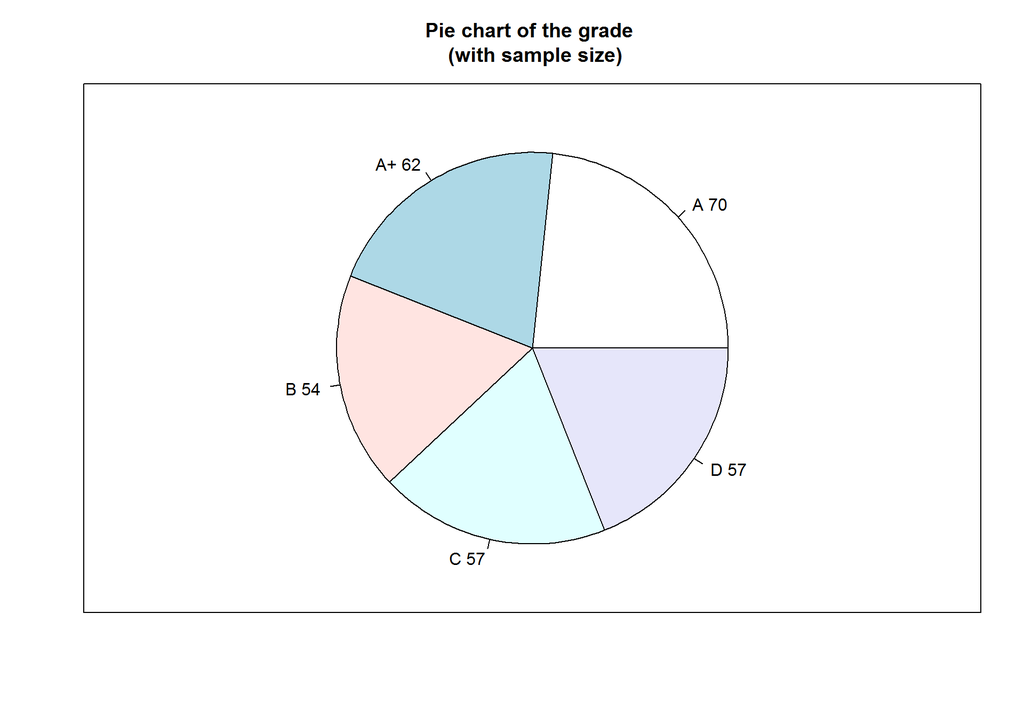

```r
y <- table(grades$grade)
lb <- paste(names(y), " ", y, sep="")
pie(y, labels=lb, main= "Pie chart of the grade \n (with sample size)")
box()
```

#### Question 2.5

```r
options(digits=2)
dstats <- function(x)(c(mean=mean(x), sd=sd(x)))
aggregate(grades[,2:4], by=list(grade=grades$grade), dstats)
```

```
##   grade Math.mean Math.sd Chinese.mean Chinese.sd English.mean English.sd
## 1     A      83.9     6.7         82.2        5.6         87.3        5.6
## 2    A+      90.1     6.4         83.3        4.3         92.4        5.3
## 3     B      80.6     5.7         80.9        5.7         84.8        4.7
## 4     C      76.5     5.9         82.1        4.7         81.5        5.1
## 5     D      70.7     6.0         81.6        5.4         74.7        6.5
```

### Question 3

#### Question 3.1

Regress `Math` on `Chinese` and `English`.

```r
fit<-lm(Math~Chinese+English,data=grades)
summary(fit)
```

```
##
## Call:
## lm(formula = Math ~ Chinese + English, data = grades)
##
## Residuals:
##    Min     1Q Median     3Q    Max
## -20.59  -5.53  -0.32   5.50  20.95
##
## Coefficients:
##             Estimate Std. Error t value Pr(>|t|)
## (Intercept)  80.0629     9.6124    8.33  3.0e-15 ***
## Chinese      -0.3751     0.0919   -4.08  5.7e-05 ***
## English       0.3719     0.0596    6.24  1.5e-09 ***
## ---
## Signif. codes:  0 '***' 0.001 '**' 0.01 '*' 0.05 '.' 0.1 ' ' 1
##
## Residual standard error: 8.2 on 297 degrees of freedom
## Multiple R-squared:  0.176,  Adjusted R-squared:  0.171
## F-statistic: 31.8 on 2 and 297 DF,  p-value: 3.14e-13
```

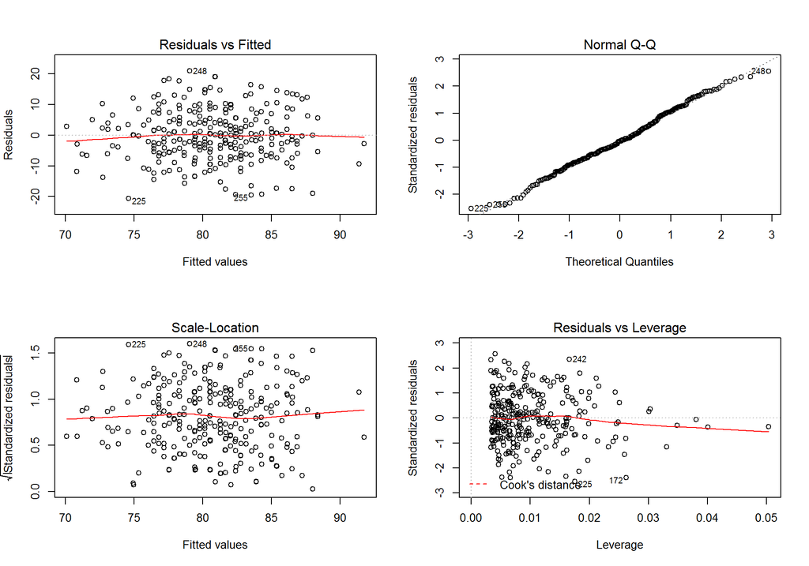

```r
par(mfrow=c(2,2))
plot(fit)
```

#### Question 3.2

Now I plot a histogram of the studentized residuals below and superimposes a normal curve, kernel density curve and rug plot.

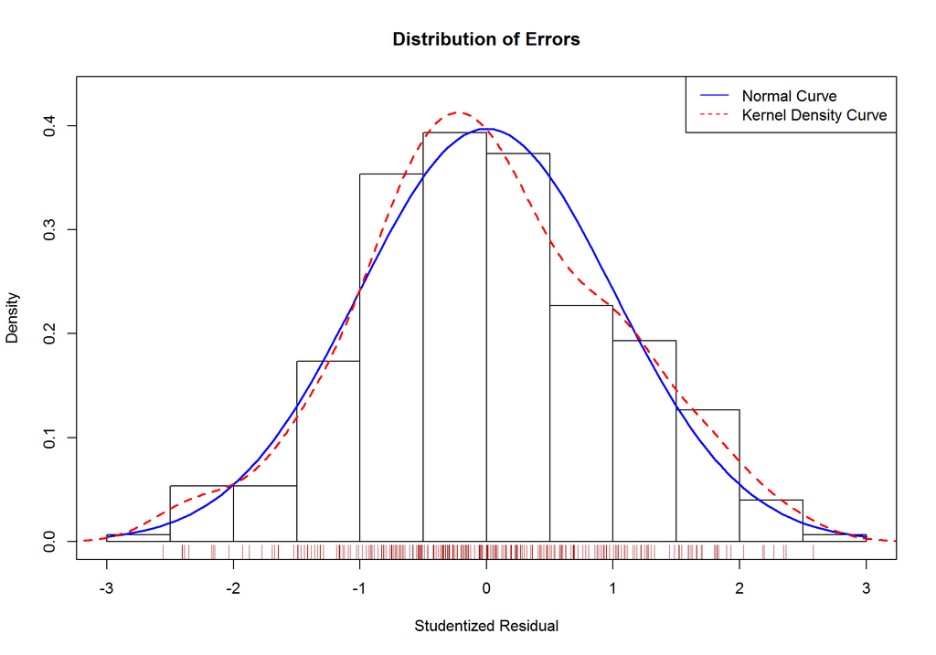

```r
z <- rstudent(fit)
hist(z, breaks=13, freq=FALSE,ylim=c(0,0.43), xlab="Studentized Residual",main="Distribution of Errors")
rug(jitter(z), col="brown")
curve(dnorm(x, mean=mean(z), sd=sd(z)), add=TRUE, col="blue", lwd=2)
lines(density(z)$x, density(z)$y, col="red", lwd=2, lty=2)
legend("topright",legend = c( "Normal Curve", "Kernel Density Curve"),lty=1:2, col=c("blue","red"), cex=1)
box()
```

[Return to the homepage.](http://xiaojunsun.github.io/wise-r-club/)

WISE R Club project is proudly maintained by XiaojunSun.